# Unsupervised learning - clustering and dimension reduction

Anna Yeaton

Fall 2019

# Lab Section

Download auto data from the *Statistical Learning* book website here: http://www-bcf.usc.edu/~gareth/ISL/data.html

Today, we are going over Hierarchical clustering, K-Means Clustering, PCA, and ICA.

```r
# read in Auto data
Auto_data <- read_csv("/Users/ericachio/Documents/sackler/machine learning/hw1-ericachio/Auto.csv")
#remove cars with unknown horsepower and set horsepower to numeric
Auto_data <- Auto_data %>%
  filter(horsepower != "?") %>%
  mutate(horsepower = as.numeric(horsepower)) %>%
  as.data.frame()

#save car names
Auto_data_names <- Auto_data$name

#data to cluster
Auto_data_clust <- Auto_data[,1:8]
dim(Auto_data_clust)
```

```
## [1] 392   8
```

```r
#392 is too much for a demo, so lets take the first 25
Auto_data_clust <- Auto_data_clust[1:25,]
rownames(Auto_data_clust) <- Auto_data_names[1:25]
```

## Hierarchical agglomerative clustering

Step 1. Assign each item to it’s own cluster. We start with 25 clusters, one for each car.

Step 2. Calculate a proximity matrix between each cluster.

Step 3. Find the pair of clusters closest to each other.

Step 4. Merge these clusters and then recalculate similarity between clusters. Some options are: single linkage (distance is calculated from the nearest neighbors), complete linkage (distance is calculated from furthest neighbor), average linkage (distance is calculated from mean of different clusters).

Step 5. Repeat Step 3 and 4 until there is only one cluster.

### In practice

Step 1. Each car is a cluster.

Step 2. Create a distance matrix from Auto_data_clust.

```r
help("dist")
```

```
## Help on topic 'dist' was found in the following packages:
##
##   Package               Library
##   factoextra            /Library/Frameworks/R.framework/Versions/3.6/Resources/library
##   stats                 /Library/Frameworks/R.framework/Versions/3.6/Resources/library
##
##
## Using the first match ...
```

```r
hierarchical_dist <- as.matrix(dist(Auto_data_clust, method = "euclidean"))
#View(hierarchical_dist)
```

Step 3. Find the two cars that are the most similar to each other and print the names of those two cars

```r
diag(hierarchical_dist) <- NA
arrayInd(which.min(hierarchical_dist), dim(hierarchical_dist))
```

```
##      [,1] [,2]
## [1,]   23   15
```

```r
#postitions 23 and 15 are the most similar. Lets go back to the names of the cars
Auto_data_names[23]
```

```
## [1] "saab 99e"
```

```r
Auto_data_names[15]
```

```
## [1] "toyota corona mark ii"
```

Step 4. Merge the two clusters together using average linkage.

```r
#replace pos 15 with the average of pos 15 and 23
hierarchical_dist[,15] <- apply((hierarchical_dist[,c(23,15)]),1,mean)
hierarchical_dist[15,] <- apply((hierarchical_dist[c(23,15),]),2,mean)

#remove pos 23
hierarchical_dist <- hierarchical_dist[-23,-23]

#now position 15 represents the cluster containing the saab99e and the toyota corona mark ii
```

Step 5. To complete the algorithm, go back to step 3 and iterate through all of the previous steps until there are no more rows left

```r
diag(hierarchical_dist) <- NA
#all distances between x and x would be 0, so set to na because looking for min
arrayInd(which.min(hierarchical_dist), dim(hierarchical_dist))
```

```
##      [,1] [,2]
## [1,]    4    3
```

```r
#postitions 4 and 3 are the most similar
Auto_data_names[4]
```

```
## [1] "amc rebel sst"
```

```r
Auto_data_names[3]
```

```
## [1] "plymouth satellite"
```

### R function

Now that we know how the algorithm works, let’s use the R function hclust. Plot the Dendogram resulting from clustering the Auto_data_clust using average linkage.

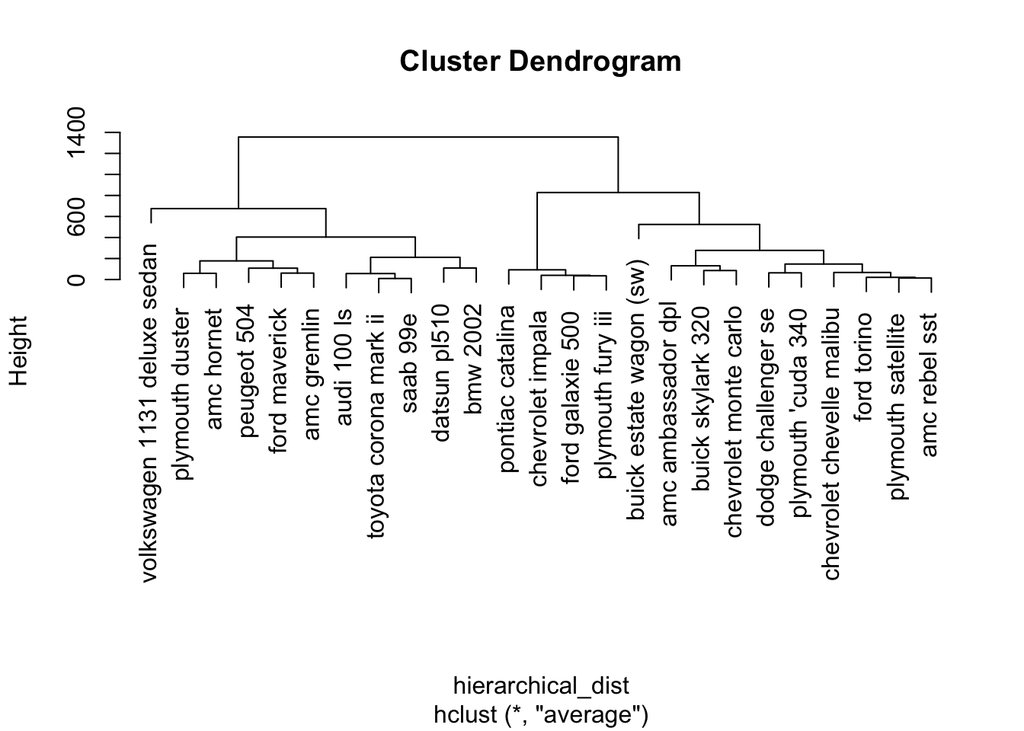

```r
hierarchical_dist <- dist(Auto_data_clust, method = "euclidean")
tree <- hclust(hierarchical_dist, method="average")
plot(tree)
```

There is one more element to hierarchical clustering: Cutting the tree. Here, we can control how many clusters we want or the height of the tree.

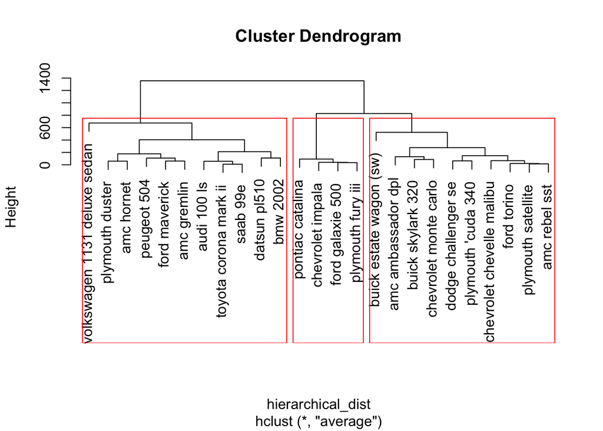

```r
#help(cutree)

# cut tree into 3 clusters
tree <- hclust(hierarchical_dist, method="average")
plot(tree)
tree_k2 <- cutree(tree, k = 2)
# plot the tree before running this line
rect.hclust(tree, k = 3, h = NULL)
```

## Principal Components Analysis (PCA)

Principal Components Analysis is a linear dimensionality reduction algorithm. If you want to learn more about linear algebra, I suggest the MIT Open Courseware class here : https://ocw.mit.edu/courses/mathematics/18-06-linear-algebra-spring-2010/ There are two ways of doing PCA, Single Value Decomposition (SVD), and the method we will use today, using the covariance matrix of the data.

Step 1. Center data by subtracting the mean.

Step 2. Calculate covariance matrix of data.

Step 3. Perform Eigendecomposition of the covariance matrix. i.e. represent the matrix in terms of it’s eigenvalues and eigen vectors

Step 4. Multiply the eigen vectors by the original data to express the data in terms of the eigen vectors.

Step 1. Center the data by subtracting the mean of the each column from the values in that column

```r
Auto_data_clust_pca <- data.matrix(Auto_data_clust)

Center_auto <- apply(Auto_data_clust_pca, 2, function(x) x - mean(x))
```

Step 2. Calculate covariance matrix of the Auto data -result in a square matrix -doing it by hand must be in a square matrix

```r
Covariance_auto <- cov(Center_auto)
```

Step 3. Calculate eigen values and vectors -eigenvectors the axis of the highest variation

```r
Eigen_value_auto <- eigen(Covariance_auto)$value

#columns are the eigen vectors
Eigen_vector_auto <- eigen(Covariance_auto)$vector
```

Step 4. Multiply the eigen vector matrix by the original data. -changing orientation of data by multiplying by eigen vector (8x8?) -changing 8 values that equate to cars -now that we shifted, plot to ggplot

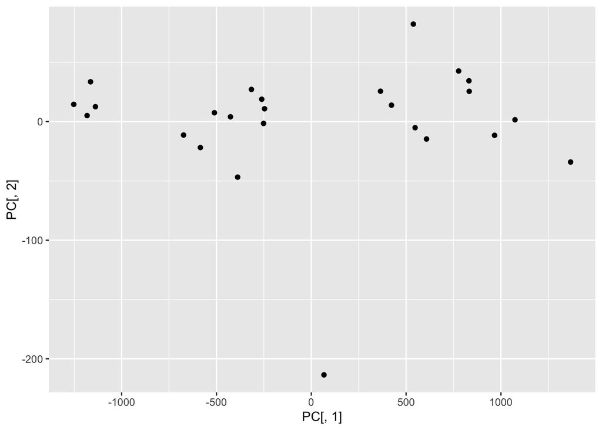

```r
PC <- as.data.frame(data.matrix(Center_auto) %*% Eigen_vector_auto)

ggplot(PC, aes(PC[,1], PC[,2])) + geom_point(aes(PC[,1], PC[,2]))
```

```r
#+ geom_text(aes(label=Auto_data_names[1:8]), nudge_x = -2.5, nudge_y = 400)
```

Step 5. Find out which principal components explain the variance in the data. -changing the way data is represented to show maximum variation

```r
#for each component, take the cumulative sum of eigen values up to that point and and divide by the total sum of eigen values
round(cumsum(Eigen_value_auto)/sum(Eigen_value_auto) * 100, digits = 2)
```

```
## [1]  99.52  99.95 100.00 100.00 100.00 100.00 100.00 100.00
```

### R function

Now that we know how PCA works, lets use the R funtion prcomp.

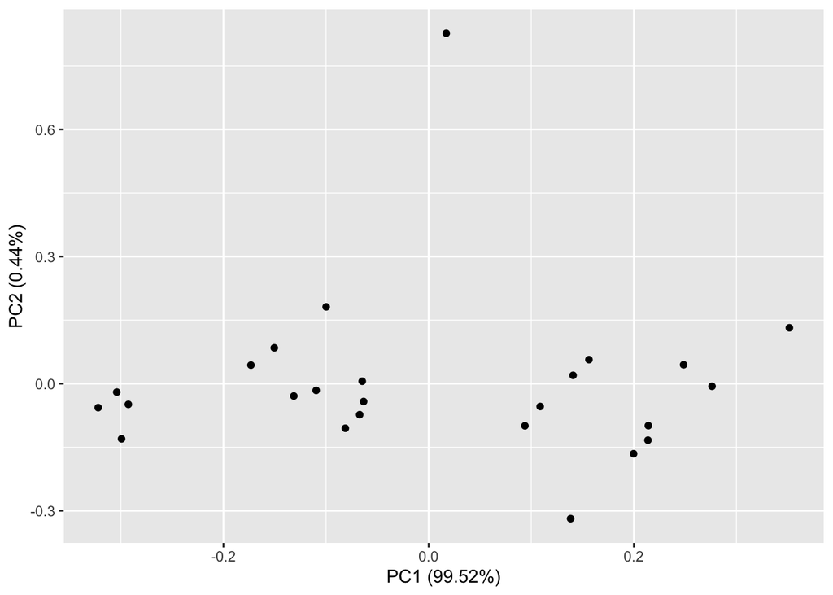

```r
help("prcomp")
autoplot(prcomp(Auto_data_clust_pca))
```